# Analyzing Happy Moments: What are the effects of happiness on human being?

Yawen Zhou

[output not shown]

[output not shown]

[output not shown]

[output not shown]

# Introduction

Central to our exploration is the HappyDB dataset, a rich compilation of diverse information spread across five key files:

cleaned_hm.csv: This file is an enhanced version of the original_hm.csv, offering a polished collection of happy moments. It includes reflective cycles, unique person IDs, and vivid expressions of joy.

original_hm.csv: Serving as an unfiltered reservoir of happiness, this file preserves the raw, unedited moments of joy.

Demograph.csv: This file provides a deep dive into demographic information, encompassing details like age, gender, and geographical location, adding layers of context to our analysis.

senselabel.csv: Annotated and insightful, this file enriches the cleaned-up Happy Moments with lexical details, including parts of speech tags and hyper-meaning tags, enhancing our linguistic understanding.

topic_dict/*-dict.csv: Offering a classified perspective, this file categorizes happy moments, aiding in the structured analysis of joy.

Through this project, we embark on a journey to map the contours of happiness, leveraging the eloquence of human words and the precision of data analysis. Join us as we unlock the doors to a new realm of understanding, where data narrates the story of joy.

#Data Exploration Firstly, reading the cleaned_hm.csv file, and creating a new variable cleaned_hm_1 that contains the result of the original cleaned_hm dataset after removing all rows that contain missing values.

```
##       hmid             wid        reflection_period  original_hm
##  Min.   : 27673   Min.   :    1   Length:100535      Length:100535
##  1st Qu.: 52942   1st Qu.:  410   Class :character   Class :character
##  Median : 78204   Median : 1125   Mode  :character   Mode  :character
##  Mean   : 78214   Mean   : 2747
##  3rd Qu.:103490   3rd Qu.: 3507
##  Max.   :128766   Max.   :13839
##   cleaned_hm         modified        num_sentence    ground_truth_category
##  Length:100535      Mode :logical   Min.   : 1.000   Length:100535
##  Class :character   FALSE:2206      1st Qu.: 1.000   Class :character
##  Mode  :character   TRUE :98329     Median : 1.000   Mode  :character
##                                     Mean   : 1.341
##                                     3rd Qu.: 1.000
##                                     Max.   :69.000
##  predicted_category
##  Length:100535
##  Class :character
##  Mode  :character
##
##
##
```

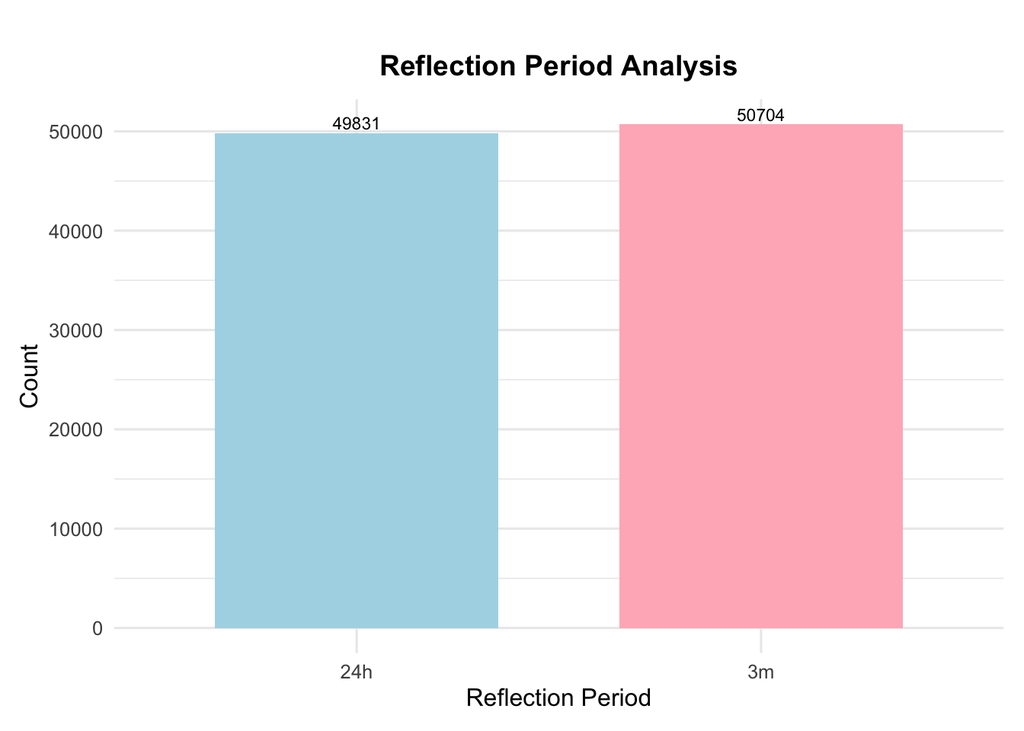

# Sentiment Analysis

Based on the sentiment analysis of over 100,000 sentences and the accompanying data, we can derive insightful conclusions about the impact of happiness on human experiences.The sentiment analysis reveals that happiness in human experiences is a rich tapestry of emotions, characterized by a dominance of positive feelings interspersed with elements of trust, anticipation, and even negative emotions. This nuanced understanding of happiness highlights its multifaceted nature and its profound impact on human life, demonstrating that happiness is not just a singular state of joy but a complex emotional experience with a wide range of influences and expressions.

[output not shown]

[output cut: 86 more lines]

```
##      anger          anticipation        disgust             fear
##  Min.   : 0.0000   Min.   : 0.0000   Min.   : 0.0000   Min.   : 0.0000
##  1st Qu.: 0.0000   1st Qu.: 0.0000   1st Qu.: 0.0000   1st Qu.: 0.0000
##  Median : 0.0000   Median : 1.0000   Median : 0.0000   Median : 0.0000
##  Mean   : 0.1073   Mean   : 0.8558   Mean   : 0.1008   Mean   : 0.1562
##  3rd Qu.: 0.0000   3rd Qu.: 1.0000   3rd Qu.: 0.0000   3rd Qu.: 0.0000
##  Max.   :13.0000   Max.   :26.0000   Max.   :13.0000   Max.   :15.0000
##       joy             sadness           surprise           trust
##  Min.   : 0.0000   Min.   : 0.0000   Min.   : 0.0000   Min.   : 0.0000
##  1st Qu.: 0.0000   1st Qu.: 0.0000   1st Qu.: 0.0000   1st Qu.: 0.0000
##  Median : 1.0000   Median : 0.0000   Median : 0.0000   Median : 1.0000
##  Mean   : 0.9355   Mean   : 0.1579   Mean   : 0.3514   Mean   : 0.8257
##  3rd Qu.: 1.0000   3rd Qu.: 0.0000   3rd Qu.: 1.0000   3rd Qu.: 1.0000
##  Max.   :28.0000   Max.   :15.0000   Max.   :18.0000   Max.   :26.0000
##     negative          positive
##  Min.   : 0.0000   Min.   : 0.000
##  1st Qu.: 0.0000   1st Qu.: 0.000
##  Median : 0.0000   Median : 1.000
##  Mean   : 0.2724   Mean   : 1.378
##  3rd Qu.: 0.0000   3rd Qu.: 2.000
##  Max.   :32.0000   Max.   :43.000
```

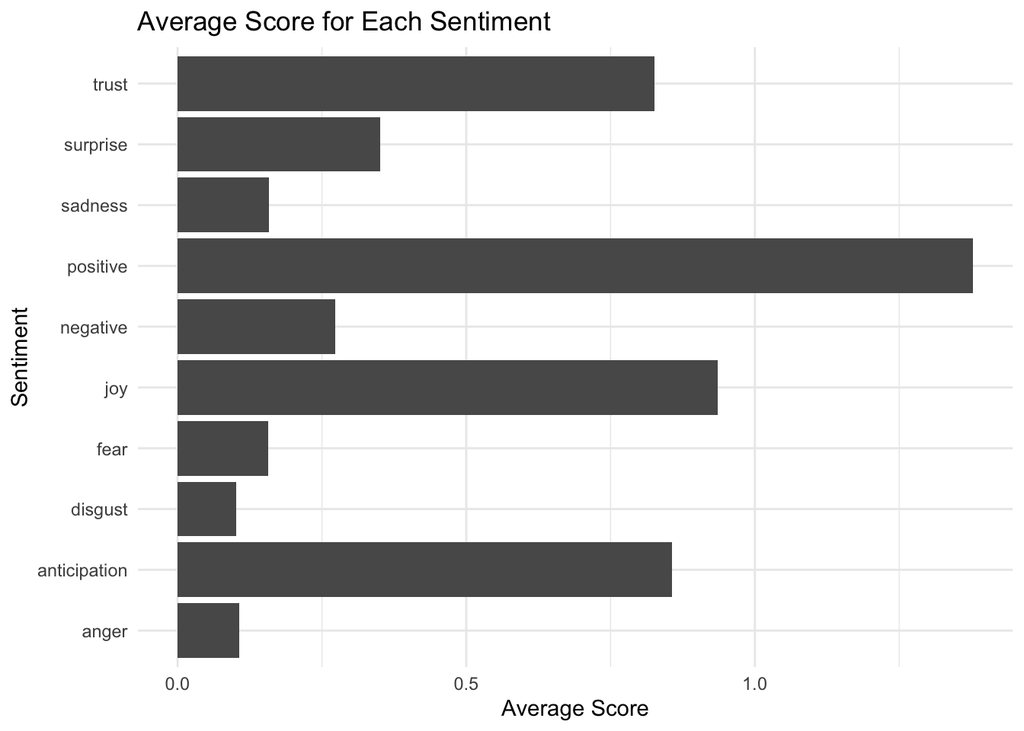

# Happiness and influencing factors

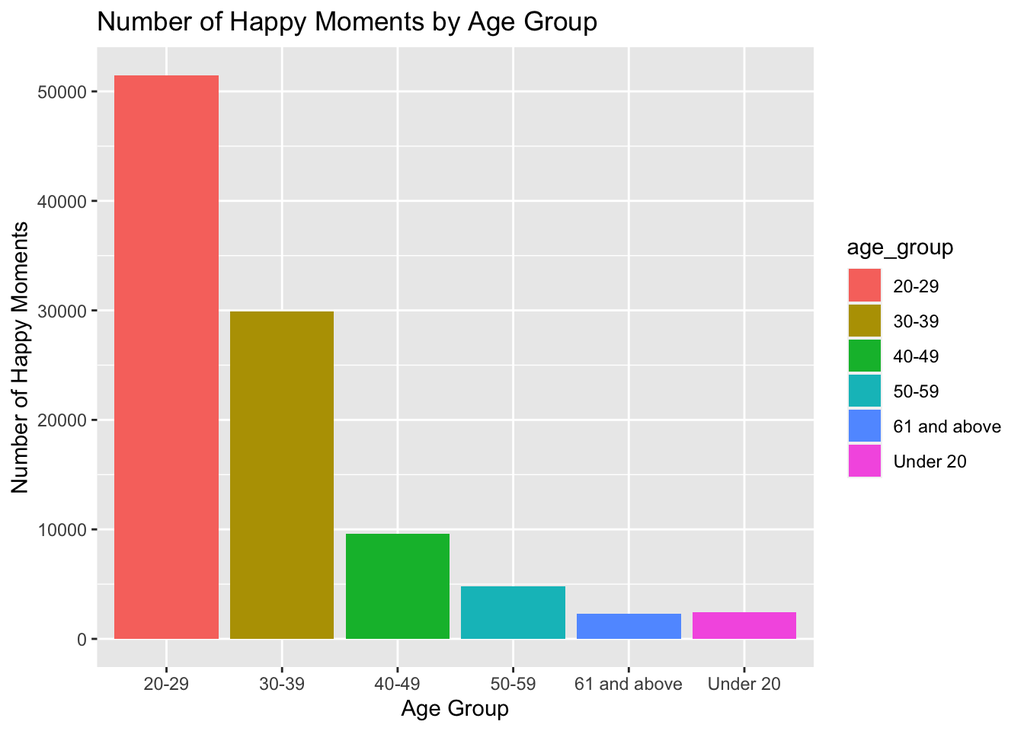

   2.Gender and Happiness Sharing: The analysis shows a significant difference in the number of happy moments shared between genders, with men sharing more than women. This discrepancy could suggest that men are more active in social events or on sharing platforms, or it could indicate a higher proportion of male users in the survey or platform.

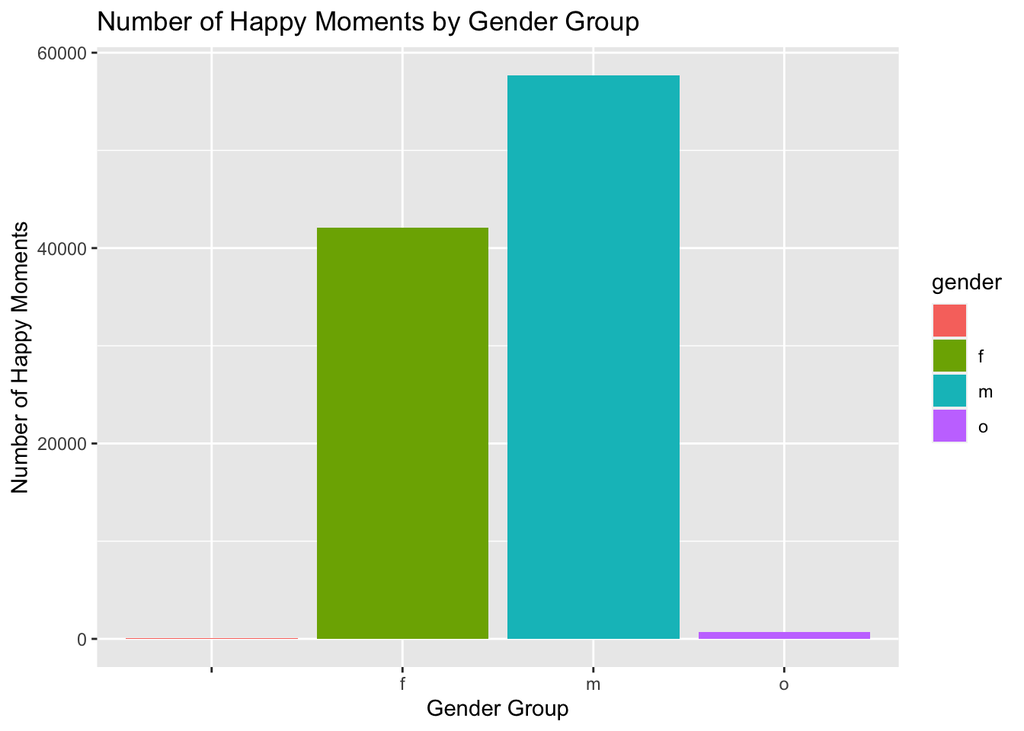

```r
# Visualization:

ggplot(gender_analysis, aes(x = gender, y = n, fill=gender)) +
  geom_bar(stat = "identity") +
  xlab("Gender Group") +
  ylab("Number of Happy Moments") +
  ggtitle("Number of Happy Moments by Gender Group")
```

3.Regional Influence on Happiness: The data indicates that participants from the USA shared the most number of happy moments. This likely reflects the demographic distribution of the survey or platform’s user base rather than pointing to regional differences in experiencing or expressing happiness.

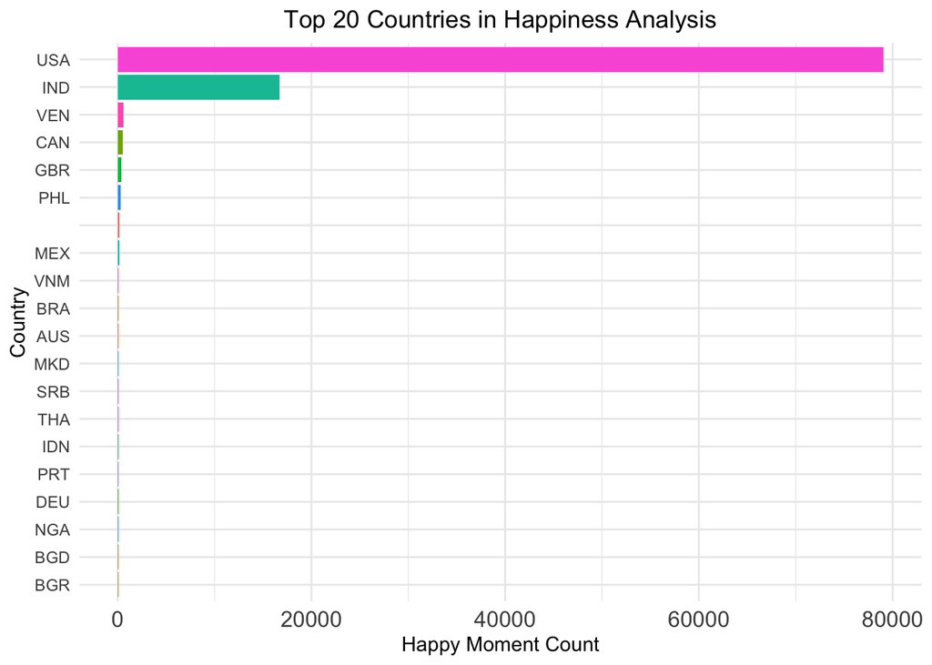

In summary, the experience and expression of happiness are influenced by a variety of factors, including age, gender, and region. While sharing and expressing happy moments is a common human trait, the way and frequency of this expression vary significantly across different demographic groups. These variations highlight the subjective nature of happiness, suggesting that happiness is experienced and communicated differently based on individual life stages, cultural backgrounds, and social contexts. Thus, the impact of happiness on people is a complex interplay of personal, social, and cultural factors, demonstrating the rich and diverse ways in which happiness manifests in our lives.

[output not shown]

[output not shown]

[output not shown]

#Word clouds analysis Together, these word clouds suggest that happiness is not merely a fleeting emotion but a complex construct influenced by a range of experiences and interactions. The words and labels that frequently appear in descriptions of happy moments reflect the multifaceted nature of happiness and its significant impact on human well-being. Social interactions, emotional expressions, personal achievements, and time spent with loved ones are all integral components that contribute to the rich tapestry of happiness in human life.

[output not shown]

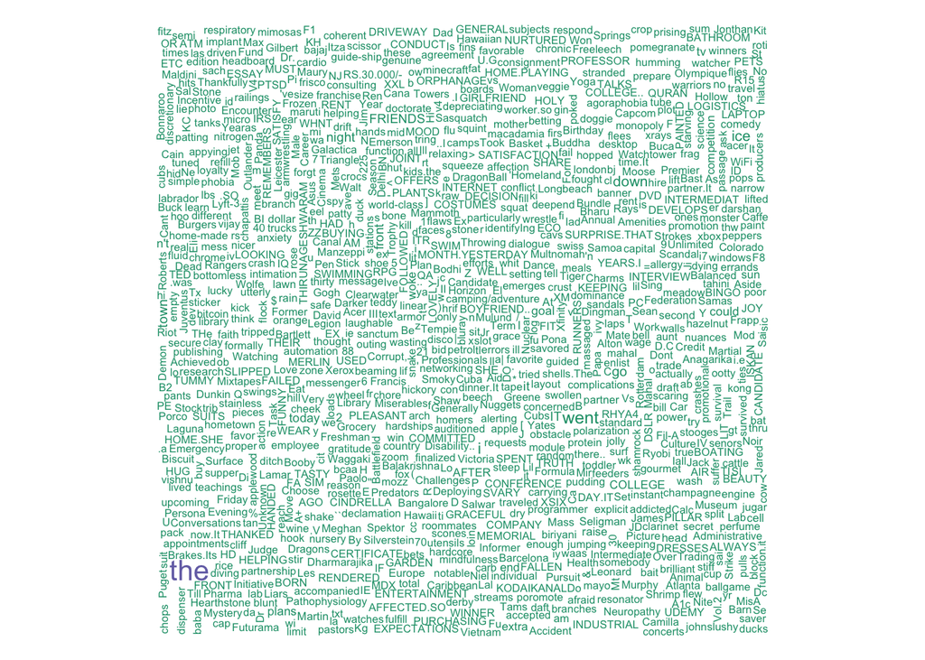

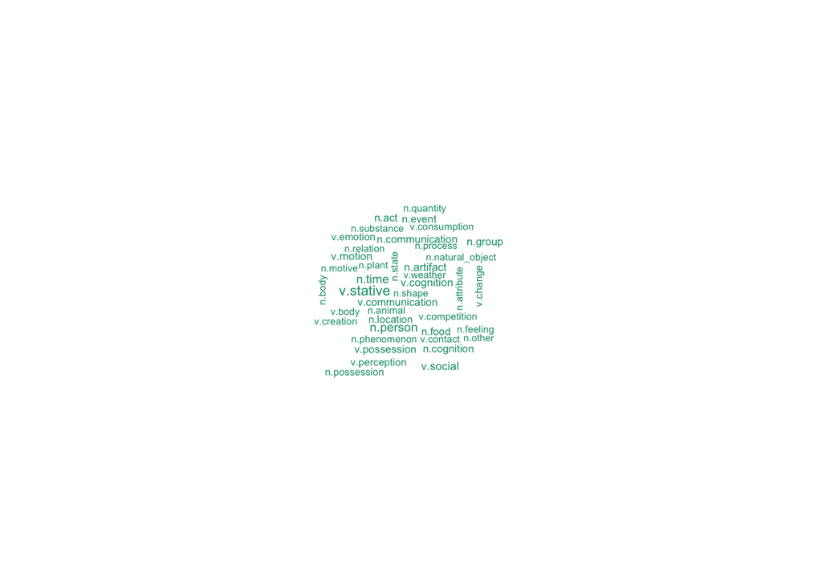

# Summary

1.Temporal Reach of Happiness: Our investigation reveals that happiness holds a temporal depth, affecting individuals equally whether reflected upon after a day or savored over months. This suggests happiness has a lasting resonance, extending its embrace far beyond the moment of experience.

2.Emotional Complexity: The sentiment analysis from myriad recounted joys paints happiness not as a single hue of joy but as a palette of emotions. Trust, anticipation, and even shades of negativity contribute to a rich emotional landscape, illustrating the complex nature of happiness.

3.Demographic Diversity: Finally, happiness emerges as a subjective phenomenon, intricately shaped by the variables of age, gender, and cultural context. The expression and experience of happiness are as varied as the individuals themselves, highlighting the personal and cultural fabric that weaves unique experiences of joy.

# References

Akari Asai, Sara Evensen, Behzad Golshan, Alon Halevy, Vivian Li, Andrei Lopatenko, Daniela Stepanov, Yoshihiko Suhara, Wang-Chiew Tan, Yinzhan Xu, ``HappyDB: A Corpus of 100,000 Crowdsourced Happy Moments’’, LREC ’18, May 2018. (to appear)